# CLUA farmer registration

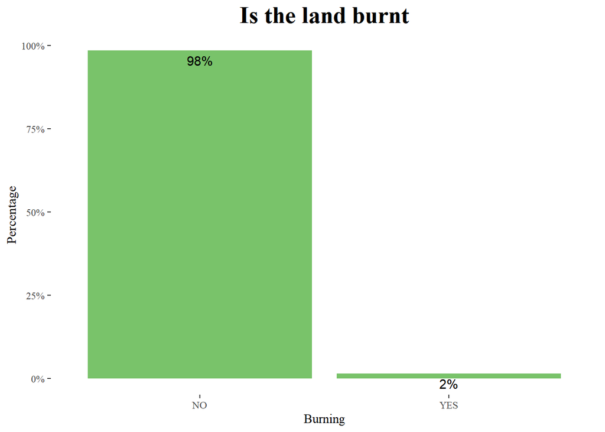

```r
df3 %>%drop_na(farm_management.burning) %>%  ggplot(aes(farm_management.burning))+
  geom_bar(fill = "#79c36a", aes(y = (..count..)/sum(..count..)))+
  geom_text(aes(y = ((..count..)/sum(..count..)), label = scales::percent((..count..)/sum(..count..))), stat = "count", vjust = 1.5, colour = "black")+
  scale_y_continuous(labels = percent) +
  labs(title = "Is the land burnt",
       x = "Burning",
       y="Percentage")+
  theme_tufte()+
  theme(plot.title = element_text(face = "bold", size = 20, hjust = 0.5))
```

Only 2% of the farmers said that there land is burnt.

```r
df3 <- df3 %>%
   bind_cols(split_into_multiple(.$farm_management.crop_residue, " ", "Crop_residue"))

df3$Crop_residue_1 <- as.factor(df3$Crop_residue_1)
levels(df3$Crop_residue_1) <- c("Burnt", "Left in the field", "Used as mulch", "Used as fodder", "Other")

df3$Crop_residue_2 <- as.factor(df3$Crop_residue_2)
levels(df3$Crop_residue_2) <- c("Left in the field", "Used as mulch", "Used as fodder", "Other")

df3$Crop_residue_3 <- as.factor(df3$Crop_residue_3)
levels(df3$Crop_residue_3) <- c("Burnt", "Other")

crop_residue <- df3 %>% select(Crop_residue_1, Crop_residue_2, Crop_residue_3) %>% gather(crop_residue, type)
freq(crop_residue$type) %>% kbl(caption = "Crop residue") %>%
  kable_classic(full_width = F, html_font = "Cambria")
```

Crop residue

|  | Freq | % Valid | % Valid Cum. | % Total | % Total Cum. |
| --- | --- | --- | --- | --- | --- |
| Burnt | 7 | 1.047904 | 1.047904 | 0.3934795 | 0.3934795 |
| Left in the field | 292 | 43.712575 | 44.760479 | 16.4137156 | 16.8071951 |
| Other | 96 | 14.371258 | 59.131737 | 5.3962901 | 22.2034851 |
| Used as fodder | 226 | 33.832335 | 92.964072 | 12.7037662 | 34.9072513 |
| Used as mulch | 47 | 7.035928 | 100.000000 | 2.6419337 | 37.5491849 |
| <NA> | 1111 | NA | NA | 62.4508151 | 100.0000000 |
| Total | 1779 | 100.000000 | 100.000000 | 100.0000000 | 100.0000000 |

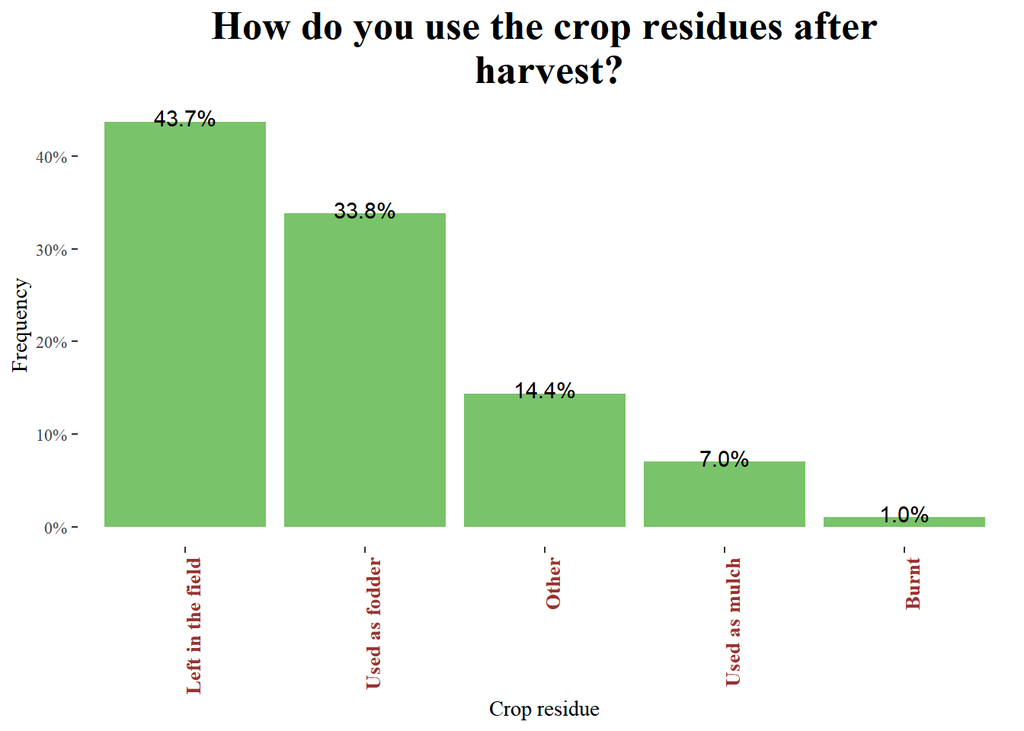

```r
crop_residue %>%drop_na(type) %>%  ggplot(aes(fct_infreq(type)))+
   geom_bar(aes(y = (..count..)/sum(..count..)), fill = "#79c36a") +
  geom_text(aes(y = ((..count..)/sum(..count..)), label = scales::percent((..count..)/sum(..count..))), stat = "count", vjust = 0.25) +
  scale_y_continuous(labels = percent) +
  labs(title = "How do you use the crop residues after\n harvest?",
       x = "Crop residue",
       y = "Frequency")+
  theme_tufte()+
  theme(plot.title = element_text(face = "bold", size = 20, hjust = 0.5),
        axis.text.x = element_text(face = "bold", color = "#993333",
                           size = 10,angle = 90, hjust = 1))
```

Most of the crop residues after harvest were left in the field that is 43.7%, 33.8% was used as fodder and only 7% was as mulch.

```r
table(df3$farm_management.crop_residue_other)
```

```
##
##
##                                                                              498
##                                                Coffee and pepper permanent crops
##                                                                                1
##                                                         Coffee is permanent crop
##                                                                                1
##                                                         Deep plough in the field
##                                                                                1
##                                                                         Firewood
##                                                                                1
##                                                          Give it to other farmer
##                                                                                1
##                                                         Give it to other farmers
##                                                                                1
##                                                            He sells the residues
##                                                                                3
##                                                     Incorporating into the field
##                                                                               26
##                                     Incorporating into the field while ploughing
##                                                                               44
##                           Incorporating into the field while ploughing the land.
##                                                                                1
##                        Incorporating the crop residue while ploughing the field.
##                                                                                1
##                                          Leaves of Coconut for household purpose
##                                                                                1
##                                                                             Nill
##                                                                                1
## No wastage till now. But the leaves fallen will be used as compost when they dry
##                                                                                1
##                                                                          Nothing
##                                                                                1
##                                                                  Permanent crops
##                                                                                2
##                                                                             Sell
##                                                                                2
##                                                                          Sell it
##                                                                                2
##                                                                 Sell the produce
##                                                                                2
##                      Used as compost by decomposing the residues in field itself
##                                                                                1
```

```r
table(df3$farm_management.farmyard_manure_use)
```

```
##
##   0   1
## 206 387
```

```r
df3$farm_management.farmyard_manure_use <- as.factor(df3$farm_management.farmyard_manure_use)
levels(df3$farm_management.farmyard_manure_use) <- c("NO", "YES")

freq(df3$farm_management.farmyard_manure_use)
```

```
## Frequencies
## df3$farm_management.farmyard_manure_use
## Type: Factor
##
##               Freq   % Valid   % Valid Cum.   % Total   % Total Cum.
## ----------- ------ --------- -------------- --------- --------------
##          NO    206     34.74          34.74     34.74          34.74
##         YES    387     65.26         100.00     65.26         100.00
##        <NA>      0                               0.00         100.00
##       Total    593    100.00         100.00    100.00         100.00
```

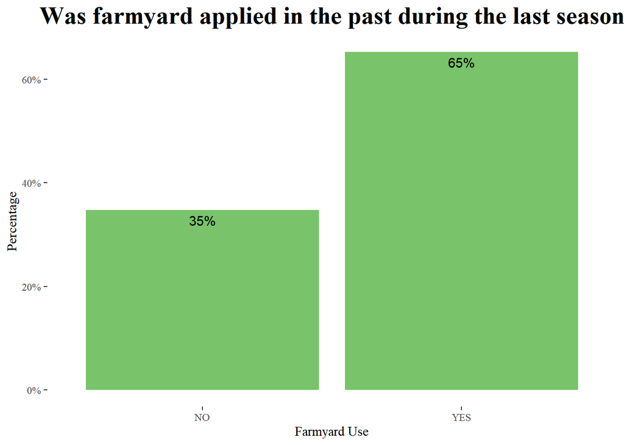

```r
df3 %>%drop_na(farm_management.farmyard_manure_use) %>%  ggplot(aes(farm_management.farmyard_manure_use))+
  geom_bar(fill = "#79c36a", aes(y = (..count..)/sum(..count..)))+
  geom_text(aes(y = ((..count..)/sum(..count..)), label = scales::percent((..count..)/sum(..count..))), stat = "count", vjust = 1.5, colour = "black")+
  scale_y_continuous(labels = percent) +
  labs(title = "Was farmyard applied in the past during the last season",
       x = "Farmyard Use",
       y="Percentage")+
  theme_tufte()+
  theme(plot.title = element_text(face = "bold", size = 20, hjust = 0.5))
```

During the last season farmyard was only applied 65% on the farms.

```r
df3 <- df3 %>%
   bind_cols(split_into_multiple(.$farm_management.manure_use_crops, " ", "manure_crops"))
df3$manure_crops_1 <- as.factor(df3$manure_crops_1)
levels(df3$manure_crops_1) <- c("Paddy", "Guord","Turmeric", "Other", "Finger millet", "Brinjal", "Red gram")

df3$manure_crops_2 <- as.factor(df3$manure_crops_2)
levels(df3$manure_crops_2) <- c("Paddy","Tubers", "Okra", "Guord","Turmeric", "Other","Finger millet", "Brinjal", "Red gram", "Cowpeas")

df3$manure_crops_3 <- as.factor(df3$manure_crops_3)
levels(df3$manure_crops_3) <- c("Tubers", "Okra", "Turmeric", "Other","Maize", "Red gram", "Cowpeas", "Beans")

df3$manure_crops_4 <- as.factor(df3$manure_crops_4)
levels(df3$manure_crops_4) <- c("Tubers", "Other","Pearl millet", "Red gram", "Cowpeas", "Beans")

df3$manure_crops_5 <- as.factor(df3$manure_crops_5)
levels(df3$manure_crops_5) <- c("Okra", "Red gram", "Cowpeas")

df3$manure_crops_6 <- as.factor(df3$manure_crops_6)
levels(df3$manure_crops_6) <- c( "Brinjal", "Red gram")

df3$manure_crops_7 <- as.factor(df3$manure_crops_7)
levels(df3$manure_crops_7) <- c("Maize", "Brinjal")

df3$manure_crops_8 <- as.factor(df3$manure_crops_8)
levels(df3$manure_crops_8) <- c("Pearl millet","Maize")

df3$manure_crops_9 <- as.factor(df3$manure_crops_9)
levels(df3$manure_crops_9) <- c("Pearl millet")

manure_crops <- df3 %>% select(manure_crops_1, manure_crops_2, manure_crops_3, manure_crops_4, manure_crops_5, manure_crops_6, manure_crops_7, manure_crops_8, manure_crops_9) %>% gather(manure_crops, type)
freq(manure_crops$type) %>% kbl(caption = "Manure crops") %>%
  kable_classic(full_width = F, html_font = "Cambria")
```

Manure crops

|  | Freq | % Valid | % Valid Cum. | % Total | % Total Cum. |
| --- | --- | --- | --- | --- | --- |
| Beans | 3 | 0.6012024 | 0.6012024 | 0.0562114 | 0.0562114 |
| Brinjal | 6 | 1.2024048 | 1.8036072 | 0.1124227 | 0.1686341 |
| Cowpeas | 8 | 1.6032064 | 3.4068136 | 0.1498969 | 0.3185310 |
| Finger millet | 38 | 7.6152305 | 11.0220441 | 0.7120105 | 1.0305415 |
| Guord | 3 | 0.6012024 | 11.6232465 | 0.0562114 | 1.0867529 |
| Maize | 5 | 1.0020040 | 12.6252505 | 0.0936856 | 1.1804384 |
| Okra | 10 | 2.0040080 | 14.6292585 | 0.1873712 | 1.3678096 |
| Other | 235 | 47.0941884 | 61.7234469 | 4.4032228 | 5.7710324 |
| Paddy | 144 | 28.8577154 | 90.5811623 | 2.6981450 | 8.4691774 |
| Pearl millet | 4 | 0.8016032 | 91.3827655 | 0.0749485 | 8.5441259 |
| Red gram | 22 | 4.4088176 | 95.7915832 | 0.4122166 | 8.9563425 |
| Tubers | 3 | 0.6012024 | 96.3927856 | 0.0562114 | 9.0125539 |
| Turmeric | 18 | 3.6072144 | 100.0000000 | 0.3372681 | 9.3498220 |
| <NA> | 4838 | NA | NA | 90.6501780 | 100.0000000 |
| Total | 5337 | 100.0000000 | 100.0000000 | 100.0000000 | 100.0000000 |

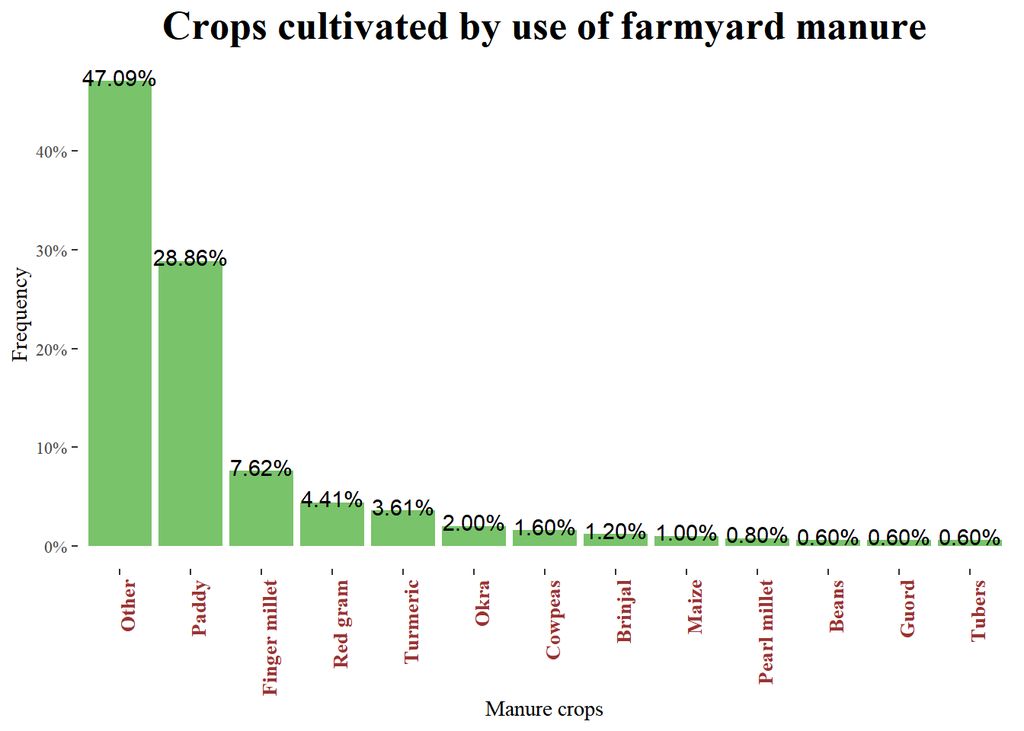

```r
manure_crops %>%drop_na(type) %>%  ggplot(aes(fct_infreq(type)))+
   geom_bar(aes(y = (..count..)/sum(..count..)), fill = "#79c36a") +
  geom_text(aes(y = ((..count..)/sum(..count..)), label = scales::percent((..count..)/sum(..count..))), stat = "count", vjust = 0.25) +
  scale_y_continuous(labels = percent) +
  labs(title = "Crops cultivated by use of farmyard manure",
       x = "Manure crops",
       y = "Frequency")+
  theme_tufte()+
  theme(plot.title = element_text(face = "bold", size = 20, hjust = 0.5),
        axis.text.x = element_text(face = "bold", color = "#993333",
                           size = 10,angle = 90, hjust = 1))
```

Crops that were cultivated by use of manure are as follows paddy, finger millet, red gram and turmeric. those were the top crops.

```r
table(df3$farm_management.compost_use)
```

```
##
##   0   1
## 431 162
```

```r
df3$farm_management.compost_use <- as.factor(df3$farm_management.compost_use)
levels(df3$farm_management.compost_use) <- c("NO", "YES")

freq(df3$farm_management.compost_use)
```

```
## Frequencies
## df3$farm_management.compost_use
## Type: Factor
##
##               Freq   % Valid   % Valid Cum.   % Total   % Total Cum.
## ----------- ------ --------- -------------- --------- --------------
##          NO    431     72.68          72.68     72.68          72.68
##         YES    162     27.32         100.00     27.32         100.00
##        <NA>      0                               0.00         100.00
##       Total    593    100.00         100.00    100.00         100.00
```

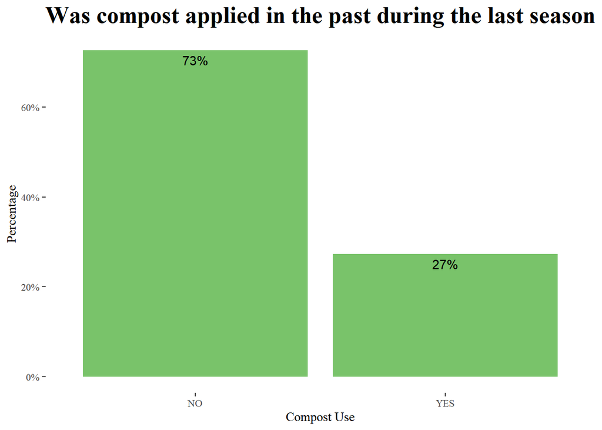

```r
df3 %>%drop_na(farm_management.compost_use) %>%  ggplot(aes(farm_management.compost_use))+
  geom_bar(fill = "#79c36a", aes(y = (..count..)/sum(..count..)))+
  geom_text(aes(y = ((..count..)/sum(..count..)), label = scales::percent((..count..)/sum(..count..))), stat = "count", vjust = 1.5, colour = "black")+
  scale_y_continuous(labels = percent) +
  labs(title = "Was compost applied in the past during the last season",
       x = "Compost Use",
       y="Percentage")+
  theme_tufte()+
  theme(plot.title = element_text(face = "bold", size = 20, hjust = 0.5))
```

Only 27% use compost on the farms.

```r
table(df3$farm_management.compost_use_crops)
```

```
##
##                       1      1 11 6        1 14         1 2   1 2 10 14
##         431          50           1          17           4           1
##   1 2 10 16      1 2 14   1 2 14 16       10 14          14       14 16
##           1           7           3           1           7           2
##        14 2        14 6       15 16          16  16 13 11 6       16 15
##           1           1           9          20           1           1
##           2     2 11 14        2 14     2 14 10     2 14 16        2 15
##           8           1           9           1           6           1
##     2 15 10        2 16   2 5 14 16 2 5 6 15 16      2 6 16   4 5 10 11
##           1           3           1           1           1           1
##        6 14
##           1
```

```r
df3 <- df3 %>%
   bind_cols(split_into_multiple(.$farm_management.compost_use_crops, " ", "compost_crops"))

df3$compost_crops_1 <- as.factor(df3$compost_crops_1)
levels(df3$compost_crops_1) <- c("Paddy","Tubers", "Turmeric", "Pepper", "Other", "Finger millet", "Pearl millet", "Brinjal")

df3$compost_crops_2 <- as.factor(df3$compost_crops_2)
levels(df3$compost_crops_2) <- c("Okra", "Guord","Turmeric", "Pepper", "Other", "Finger millet", "Maize", "Brinjal")

df3$compost_crops_3 <- as.factor(df3$compost_crops_3)
levels(df3$compost_crops_3) <- c("Tubers", "Okra", "Turmeric", "Other", "Brinjal")

df3$compost_crops_4 <- as.factor(df3$compost_crops_4)
levels(df3$compost_crops_4) <- c("Okra", "Turmeric", "Pepper", "Other", "Brinjal")

df3$compost_crops_5 <- as.factor(df3$compost_crops_5)
levels(df3$compost_crops_5) <- c("Other")

compost_crops <- df3 %>% select(compost_crops_1, compost_crops_2, compost_crops_3, compost_crops_4, compost_crops_5) %>% gather(compost_crops, type)
freq(compost_crops$type) %>% kbl(caption = "Compost crops") %>%
  kable_classic(full_width = F, html_font = "Cambria")
```

Compost crops

|  | Freq | % Valid | % Valid Cum. | % Total | % Total Cum. |
| --- | --- | --- | --- | --- | --- |
| Brinjal | 6 | 2.1739130 | 2.173913 | 0.2023609 | 0.2023609 |
| Finger millet | 50 | 18.1159420 | 20.289855 | 1.6863406 | 1.8887015 |
| Guord | 1 | 0.3623188 | 20.652174 | 0.0337268 | 1.9224283 |
| Maize | 3 | 1.0869565 | 21.739130 | 0.1011804 | 2.0236088 |
| Okra | 4 | 1.4492754 | 23.188406 | 0.1349073 | 2.1585160 |
| Other | 49 | 17.7536232 | 40.942029 | 1.6526138 | 3.8111298 |
| Paddy | 84 | 30.4347826 | 71.376812 | 2.8330523 | 6.6441821 |
| Pearl millet | 1 | 0.3623188 | 71.739130 | 0.0337268 | 6.6779089 |
| Pepper | 13 | 4.7101449 | 76.449275 | 0.4384486 | 7.1163575 |
| Tubers | 6 | 2.1739130 | 78.623188 | 0.2023609 | 7.3187184 |
| Turmeric | 59 | 21.3768116 | 100.000000 | 1.9898820 | 9.3086003 |
| <NA> | 2689 | NA | NA | 90.6913997 | 100.0000000 |
| Total | 2965 | 100.0000000 | 100.000000 | 100.0000000 | 100.0000000 |

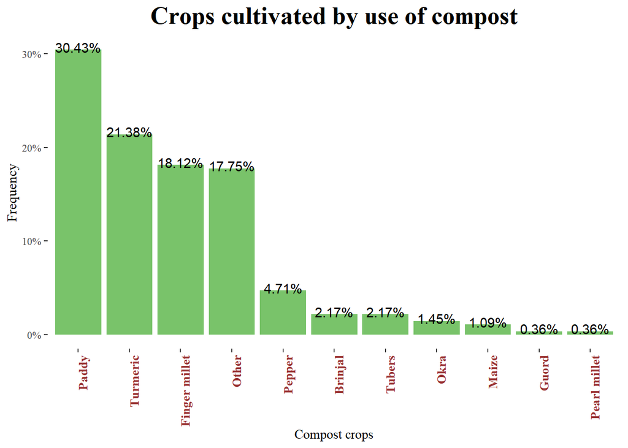

```r
compost_crops %>%drop_na(type) %>%  ggplot(aes(fct_infreq(type)))+
   geom_bar(aes(y = (..count..)/sum(..count..)), fill = "#79c36a") +
  geom_text(aes(y = ((..count..)/sum(..count..)), label = scales::percent((..count..)/sum(..count..))), stat = "count", vjust = 0.25) +
  scale_y_continuous(labels = percent) +
  labs(title = "Crops cultivated by use of compost",
       x = "Compost crops",
       y = "Frequency")+
  theme_tufte()+
  theme(plot.title = element_text(face = "bold", size = 20, hjust = 0.5),
        axis.text.x = element_text(face = "bold", color = "#993333",
                           size = 10,angle = 90, hjust = 1))
```

Crops that were with compost are Paddy 30.43%, Turmeric 21.38% and finger millet 18.12%.

```r
table(df3$farm_management.mulch_use)
```

```
##
##   0   1
## 576  17
```

```r
df3$farm_management.mulch_use <- as.factor(df3$farm_management.mulch_use)
levels(df3$farm_management.mulch_use) <- c("NO", "YES")

freq(df3$farm_management.mulch_use)
```

```
## Frequencies
## df3$farm_management.mulch_use
## Type: Factor
##
##               Freq   % Valid   % Valid Cum.   % Total   % Total Cum.
## ----------- ------ --------- -------------- --------- --------------
##          NO    576     97.13          97.13     97.13          97.13
##         YES     17      2.87         100.00      2.87         100.00
##        <NA>      0                               0.00         100.00
##       Total    593    100.00         100.00    100.00         100.00
```

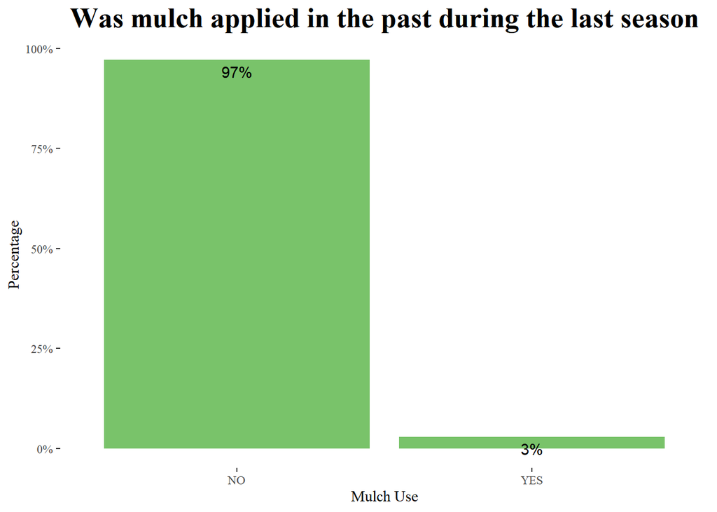

```r
df3 %>%drop_na(farm_management.mulch_use) %>%  ggplot(aes(farm_management.mulch_use))+
  geom_bar(fill = "#79c36a", aes(y = (..count..)/sum(..count..)))+
  geom_text(aes(y = ((..count..)/sum(..count..)), label = scales::percent((..count..)/sum(..count..))), stat = "count", vjust = 1.5, colour = "black")+
  scale_y_continuous(labels = percent) +
  labs(title = "Was mulch applied in the past during the last season",
       x = "Mulch Use",
       y="Percentage")+
  theme_tufte()+
  theme(plot.title = element_text(face = "bold", size = 20, hjust = 0.5))
```

Only 3% of the farms is where mulch was applied or used in the past during the last season.

```r
df3 <- df3 %>%
   bind_cols(split_into_multiple(.$farm_management.mulch_use_crops, " ", "mulch_crops"))

df3$mulch_crops_1 <- as.factor(df3$mulch_crops_1)
levels(df3$mulch_crops_1) <- c("Turmeric", "Pepper", "Other", "Pearl millet", "Red gram", "Cowpeas")

df3$mulch_crops_2 <- as.factor(df3$mulch_crops_2)
levels(df3$mulch_crops_2) <- c("Okra", "Other", "Maize", "Red gram")

df3$mulch_crops_3 <- as.factor(df3$mulch_crops_3)
levels(df3$mulch_crops_3) <- c("Tubers", "Brinjal")

df3$mulch_crops_4 <- as.factor(df3$mulch_crops_4)
levels(df3$mulch_crops_4) <- c( "Okra", "Red gram", "Cowpeas")

df3$mulch_crops_5 <- as.factor(df3$mulch_crops_5)
levels(df3$mulch_crops_5) <- c("Tubers", "Red gram")

df3$mulch_crops_6 <- as.factor(df3$mulch_crops_6)
levels(df3$mulch_crops_6) <- c("Okra", "Brinjal")

df3$mulch_crops_7 <- as.factor(df3$mulch_crops_7)
levels(df3$mulch_crops_7) <- c("Gourd", "Maize")

df3$mulch_crops_8 <- as.factor(df3$mulch_crops_8)
levels(df3$mulch_crops_8) <- c("Other", "Pearl millet")


mulch_crops <- df3 %>% select(mulch_crops_1, mulch_crops_2, mulch_crops_3, mulch_crops_4, mulch_crops_5, mulch_crops_6, mulch_crops_7, mulch_crops_8) %>% gather(mulch_crops, type)
freq(mulch_crops$type) %>% kbl(caption = "mulch crops") %>%
  kable_classic(full_width = F, html_font = "Cambria")
```

mulch crops

|  | Freq | % Valid | % Valid Cum. | % Total | % Total Cum. |
| --- | --- | --- | --- | --- | --- |
| Brinjal | 3 | 6 | 6 | 0.0632378 | 0.0632378 |
| Cowpeas | 4 | 8 | 14 | 0.0843170 | 0.1475548 |
| Gourd | 1 | 2 | 16 | 0.0210793 | 0.1686341 |
| Maize | 3 | 6 | 22 | 0.0632378 | 0.2318718 |
| Okra | 5 | 10 | 32 | 0.1053963 | 0.3372681 |
| Other | 15 | 30 | 62 | 0.3161889 | 0.6534570 |
| Pearl millet | 3 | 6 | 68 | 0.0632378 | 0.7166948 |
| Pepper | 4 | 8 | 76 | 0.0843170 | 0.8010118 |
| Red gram | 6 | 12 | 88 | 0.1264755 | 0.9274874 |
| Tubers | 5 | 10 | 98 | 0.1053963 | 1.0328836 |
| Turmeric | 1 | 2 | 100 | 0.0210793 | 1.0539629 |
| <NA> | 4694 | NA | NA | 98.9460371 | 100.0000000 |
| Total | 4744 | 100 | 100 | 100.0000000 | 100.0000000 |

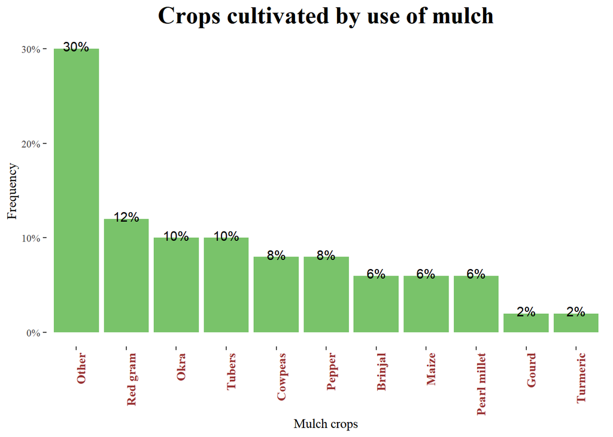

```r
mulch_crops %>%drop_na(type) %>%  ggplot(aes(fct_infreq(type)))+
   geom_bar(aes(y = (..count..)/sum(..count..)), fill = "#79c36a") +
  geom_text(aes(y = ((..count..)/sum(..count..)), label = scales::percent((..count..)/sum(..count..))), stat = "count", vjust = 0.25) +
  scale_y_continuous(labels = percent) +
  labs(title = "Crops cultivated by use of mulch",
       x = "Mulch crops",
       y = "Frequency")+
  theme_tufte()+
  theme(plot.title = element_text(face = "bold", size = 20, hjust = 0.5),
        axis.text.x = element_text(face = "bold", color = "#993333",
                           size = 10,angle = 90, hjust = 1))
```

With the mulch crops we have red grams, Okra and Tubers as top 3.

```r
df3$farm_management.chemical_fertilizer_use <- as.factor(df3$farm_management.chemical_fertilizer_use)
levels(df3$farm_management.chemical_fertilizer_use) <- c("NO", "YES")

freq(df3$farm_management.chemical_fertilizer_use)
```

```
## Frequencies
## df3$farm_management.chemical_fertilizer_use
## Type: Factor
##
##               Freq   % Valid   % Valid Cum.   % Total   % Total Cum.
## ----------- ------ --------- -------------- --------- --------------
##          NO    305     51.43          51.43     51.43          51.43
##         YES    288     48.57         100.00     48.57         100.00
##        <NA>      0                               0.00         100.00
##       Total    593    100.00         100.00    100.00         100.00
```

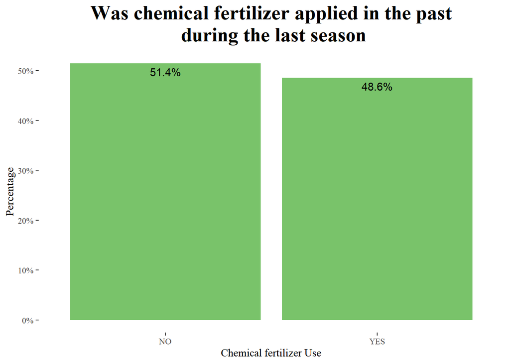

```r
df3 %>%drop_na(farm_management.chemical_fertilizer_use) %>%  ggplot(aes(farm_management.chemical_fertilizer_use))+
  geom_bar(fill = "#79c36a", aes(y = (..count..)/sum(..count..)))+
  geom_text(aes(y = ((..count..)/sum(..count..)), label = scales::percent((..count..)/sum(..count..))), stat = "count", vjust = 1.5, colour = "black")+
  scale_y_continuous(labels = percent) +
  labs(title = "Was chemical fertilizer applied in the past\n during the last season",
       x = "Chemical fertilizer Use",
       y="Percentage")+
  theme_tufte()+
  theme(plot.title = element_text(face = "bold", size = 20, hjust = 0.5))
```

Only 48.6% of the farms was where the chemical fertilzers were applied in the last season, 51.4% did not apply.

```r
df3 <- df3 %>%
   bind_cols(split_into_multiple(.$farm_management.fertilizer_use_crops, " ", "fertilizer_crops"))
df3$fertilizer_crops_1 <- as.factor(df3$fertilizer_crops_1)
levels(df3$fertilizer_crops_1) <- c("Paddy", "Other", "Finger millet", "Red gram", "Cowpeas")

df3$fertilizer_crops_2 <- as.factor(df3$fertilizer_crops_2)
levels(df3$fertilizer_crops_2) <- c("Tubers", "Okra", "Other", "Red gram")

df3$fertilizer_crops_3 <- as.factor(df3$fertilizer_crops_3)
levels(df3$fertilizer_crops_3) <- c("Other")

fertilizer_crops <- df3 %>% select(fertilizer_crops_1, fertilizer_crops_2, fertilizer_crops_3) %>% gather(fertilizer_crops, type)
freq(fertilizer_crops$type) %>% kbl(caption = "fertilizer crops") %>%
  kable_classic(full_width = F, html_font = "Cambria")
```

fertilizer crops

|  | Freq | % Valid | % Valid Cum. | % Total | % Total Cum. |
| --- | --- | --- | --- | --- | --- |
| Cowpeas | 2 | 0.6514658 | 0.6514658 | 0.1124227 | 0.1124227 |
| Finger millet | 1 | 0.3257329 | 0.9771987 | 0.0562114 | 0.1686341 |
| Okra | 1 | 0.3257329 | 1.3029316 | 0.0562114 | 0.2248454 |
| Other | 172 | 56.0260586 | 57.3289902 | 9.6683530 | 9.8931984 |
| Paddy | 120 | 39.0879479 | 96.4169381 | 6.7453626 | 16.6385610 |
| Red gram | 10 | 3.2573290 | 99.6742671 | 0.5621135 | 17.2006745 |
| Tubers | 1 | 0.3257329 | 100.0000000 | 0.0562114 | 17.2568859 |
| <NA> | 1472 | NA | NA | 82.7431141 | 100.0000000 |
| Total | 1779 | 100.0000000 | 100.0000000 | 100.0000000 | 100.0000000 |

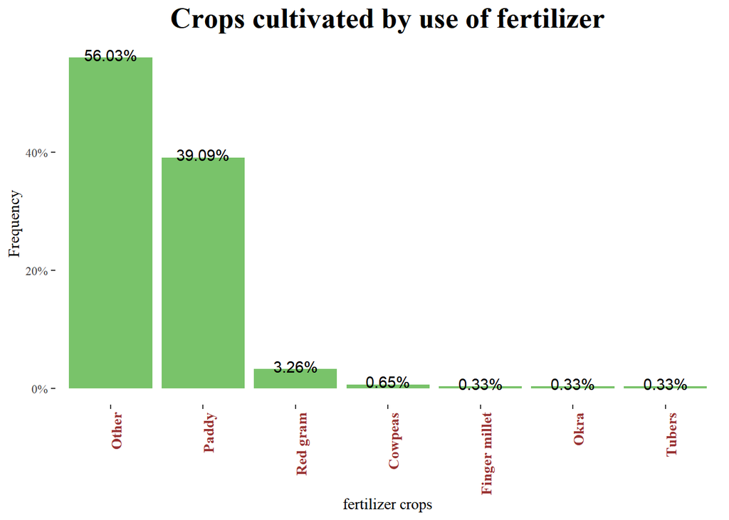

```r
fertilizer_crops %>%drop_na(type) %>%  ggplot(aes(fct_infreq(type)))+
   geom_bar(aes(y = (..count..)/sum(..count..)), fill = "#79c36a") +
  geom_text(aes(y = ((..count..)/sum(..count..)), label = scales::percent((..count..)/sum(..count..))), stat = "count", vjust = 0.25) +
  scale_y_continuous(labels = percent) +
  labs(title = "Crops cultivated by use of fertilizer",
       x = "fertilizer crops",
       y = "Frequency")+
  theme_tufte()+
  theme(plot.title = element_text(face = "bold", size = 20, hjust = 0.5),
        axis.text.x = element_text(face = "bold", color = "#993333",
                           size = 10,angle = 90, hjust = 1))
```

Other crops were the mostly used for fertilizers, then paddy and red gram.

```r
df3$farm_management.herbicide_use <- as.factor(df3$farm_management.herbicide_use)
levels(df3$farm_management.herbicide_use) <- c("NO", "YES")

freq(df3$farm_management.herbicide_use)
```

```
## Frequencies
## df3$farm_management.herbicide_use
## Type: Factor
##
##               Freq   % Valid   % Valid Cum.   % Total   % Total Cum.
## ----------- ------ --------- -------------- --------- --------------
##          NO    495     83.47          83.47     83.47          83.47
##         YES     98     16.53         100.00     16.53         100.00
##        <NA>      0                               0.00         100.00
##       Total    593    100.00         100.00    100.00         100.00
```

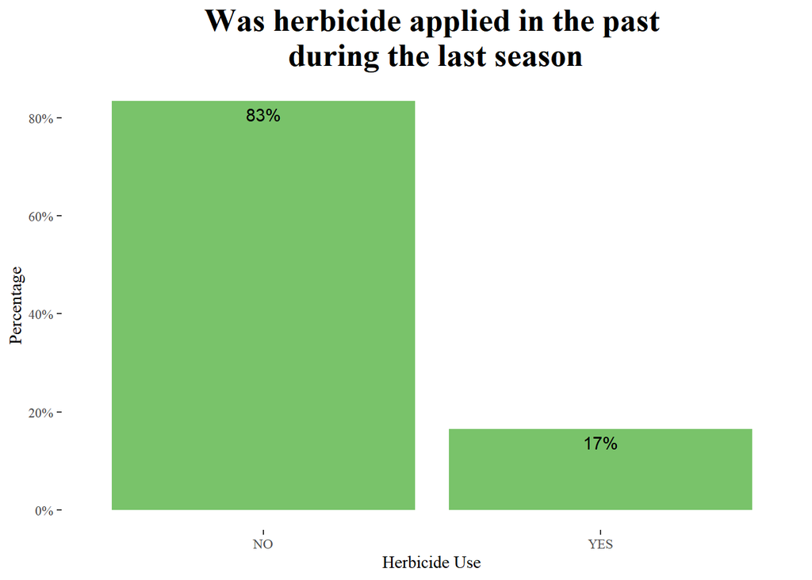

```r
df3 %>%drop_na(farm_management.herbicide_use) %>%  ggplot(aes(farm_management.herbicide_use))+
  geom_bar(fill = "#79c36a", aes(y = (..count..)/sum(..count..)))+
  geom_text(aes(y = ((..count..)/sum(..count..)), label = scales::percent((..count..)/sum(..count..))), stat = "count", vjust = 1.5, colour = "black")+
  scale_y_continuous(labels = percent) +
  labs(title = "Was herbicide applied in the past\n during the last season",
       x = "Herbicide Use",
       y="Percentage")+
  theme_tufte()+
  theme(plot.title = element_text(face = "bold", size = 20, hjust = 0.5))
```

Only 17% applied herbicides on the farms.

```r
df3$farm_management.pesticide_use <- as.factor(df3$farm_management.pesticide_use)
levels(df3$farm_management.pesticide_use) <- c("NO", "YES")

freq(df3$farm_management.pesticide_use)
```

```
## Frequencies
## df3$farm_management.pesticide_use
## Type: Factor
##
##               Freq   % Valid   % Valid Cum.   % Total   % Total Cum.
## ----------- ------ --------- -------------- --------- --------------
##          NO    319     53.79          53.79     53.79          53.79
##         YES    274     46.21         100.00     46.21         100.00
##        <NA>      0                               0.00         100.00
##       Total    593    100.00         100.00    100.00         100.00
```

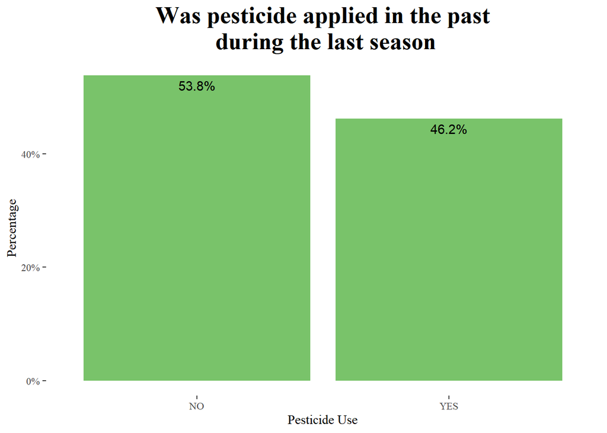

```r
df3 %>%drop_na(farm_management.pesticide_use) %>%  ggplot(aes(farm_management.pesticide_use))+
  geom_bar(fill = "#79c36a", aes(y = (..count..)/sum(..count..)))+
  geom_text(aes(y = ((..count..)/sum(..count..)), label = scales::percent((..count..)/sum(..count..))), stat = "count", vjust = 1.5, colour = "black")+
  scale_y_continuous(labels = percent) +
  labs(title = "Was pesticide applied in the past\n during the last season",
       x = "Pesticide Use",
       y="Percentage")+
  theme_tufte()+
  theme(plot.title = element_text(face = "bold", size = 20, hjust = 0.5))
```

Only 46.2% applied pesticides on the farm.